# Theoretical background of the mhn package

## 1 Scope

This vignette is the theoretical companion to *Introduction to the mhn Package*. The *Introduction* shows what the four exported functions (`dmhn` / `pmhn` / `qmhn` / `rmhn`) and their moment helpers do; this note develops the mathematical and algorithmic theory the package implements. We summarise the Modified Half-Normal (MHN) family, the Fox–Wright $\Psi$ function that appears in its normalising constant, and the two sampling schemes the package draws on — Sun, Kong & Pal (2023) and Gao & Wang (2025).

We deliberately keep the treatment compact. Full proofs and the finer numerical considerations live in the original papers (see References). Two implementation-relevant points — the typesetting errata in Sun et al. (2023) that the package silently corrects, and the benchmark-driven rationale for the `rmhn(method = "auto")` crossover at 25 — are inserted in §4 and §7 where they are most relevant.

## 2 The MHN($\alpha$, $\beta$, $\gamma$) family

The MHN distribution has support $(0, \infty)$ and density

$$f(x \mid \alpha, \beta, \gamma) =
\frac{2 \beta^{\alpha/2} \, x^{\alpha-1} \, \exp(-\beta x^2 + \gamma
x)}
{\Psi[\alpha/2,\, \gamma/\sqrt{\beta}]},
\qquad x > 0,$$

with $\alpha > 0$, $\beta > 0$, $\gamma \in \mathbb{R}$. The three parameters control three independent factors of the density kernel:

| Parameter | Factor it controls | Role |
| --- | --- | --- |
| $\alpha$ | $x^{\alpha-1}$ | shape |
| $\beta$ | $\exp(-\beta x^2)$ | Gaussian tail |
| $\gamma$ | $\exp(\gamma x)$ | exponential tilt |

Three familiar distributions sit inside the family as exact special cases (Sun et al. 2023, Lemma 6):

| Constraint | Reduction |
| --- | --- |
| $\gamma = 0$ | $X^2 \sim \mathrm{Gamma}(\alpha/2,\, \beta)$, i.e. sqrt-Gamma |
| $\alpha = 1$ | Truncated normal $\mathrm{TN}(\gamma/(2\beta),\, 1/\sqrt{2\beta},\, 0,\, \infty)$ |
| $\alpha = 1,\, \gamma = 0$ | Half-normal $\lvert Z \rvert$ with $Z \sim N(0,\, 1/(2\beta))$ |

There is also a degenerate *boundary* limit, not listed in the table: as $\beta \to 0^+$ with $\gamma < 0$, the MHN density converges to $\mathrm{Gamma}(\alpha,\, -\gamma)$. The package does not handle this limit specially because $\beta > 0$ is required by the MHN parameter space; for a Gamma draw with $\beta = 0$, use `stats::rgamma` directly.

For each of the three *finite* special cases in the table above — $\gamma = 0$, $\alpha = 1$, and both together — the package detects the constraint within `sqrt(.Machine$double.eps)` tolerance and dispatches to the corresponding closed-form primitive in `stats`, so all four exported functions (`dmhn` / `pmhn` / `qmhn` / `rmhn`) are exact in those three regimes, bypassing the general series-and-rejection machinery.

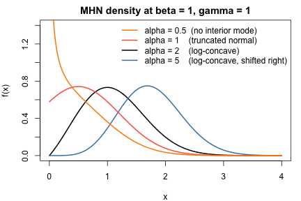

MHN density as alpha crosses the log-concavity threshold; beta = 1, gamma = 1 fixed.

```r
x  <- seq(0.001, 4, length.out = 400)
plot(x, dmhn(x, alpha = 2,   beta = 1, gamma = 1), type = "l", lwd = 2,
     ylim = c(0, 1.4), ylab = "f(x)",
     main = "MHN density at beta = 1, gamma = 1")
lines(x, dmhn(x, alpha = 5,   beta = 1, gamma = 1), lwd = 2, col = "steelblue")
lines(x, dmhn(x, alpha = 1,   beta = 1, gamma = 1), lwd = 2, col = "tomato")
lines(x, dmhn(x, alpha = 0.5, beta = 1, gamma = 1), lwd = 2, col = "darkorange")
legend("topright", bty = "n", lwd = 2,
       col = c("darkorange", "tomato", "black", "steelblue"),
       legend = c("alpha = 0.5  (no interior mode)",
                  "alpha = 1    (truncated normal)",
                  "alpha = 2    (log-concave)",
                  "alpha = 5    (log-concave, shifted right)"))
```

The figure illustrates the qualitative claims developed in the next section. The density is log-concave whenever $\alpha \geq 1$ (Sun et al. 2023, Lemma 3a). For $\alpha > 1$ it has a finite interior mode in closed form (Sun et al. 2023, Lemma 3b); the borderline case $\alpha = 1$ reduces to the truncated normal, whose mode is $\max(0,\, \gamma/(2\beta))$ — interior when $\gamma > 0$, on the boundary $x = 0$ otherwise. For $\alpha < 1$ the density is typically monotone decreasing with a boundary singularity at $x \to 0^+$. The one exception is $\gamma > 0$ together with $\alpha \geq 1 - \gamma^2/(8\beta)$, where the density is not unimodal: it diverges at $x \to 0^+$, dips to a local minimum, rises to a single interior local maximum, and then decays (Sun et al. 2023, Lemma 3c). At $(\beta, \gamma) = (1, 1)$ this threshold is $1 - 1/8 = 0.875$, so the orange ($\alpha = 0.5$) curve in the figure sits in the strict monotone-decreasing regime, with no interior local maximum.

## 3 Shape and moments

Three facts from Sun et al. (2023) drive everything the package does with shape, moments, and the mode.

**Log-concavity is a function of $\alpha$ alone** (Sun et al. 2023, Lemma 3a). For $\alpha \geq 1$ the density is log-concave irrespective of $\beta$ and $\gamma$; for $\alpha < 1$ it is not. This single threshold is what splits the Gao & Wang (2025) RTDR sampler into its log-axis and original-axis branches in §6 below.

**The mode has a closed form for $\alpha > 1$** (Sun et al. 2023, Lemma 3b):

$$X_{\mathrm{mode}}
= \frac{\gamma + \sqrt{\gamma^2 + 8\beta(\alpha -
1)}}{4\beta}.$$

For $\alpha = 1$ the mode is $\max(0,\, \gamma/(2\beta))$ (the truncated-normal mode, Sun et al. 2023, Lemma 6b). For $\alpha < 1$ the density is either monotone decreasing or develops a non-trivial local maximum and local minimum, depending on the sign of $1 - \gamma^2/(8\beta) - \alpha$ (Sun et al. 2023, Lemma 3c–d). The helper `mhn_mode()` implements this case split and returns `NA` when no interior mode exists.

**Moments satisfy a two-term recurrence** (Sun et al. 2023, Lemma 2b):

$$E(X^{k+2})
= \frac{\alpha + k}{2 \beta}\, E(X^{k})
+ \frac{\gamma}{2 \beta}\, E(X^{k+1}).$$

Together with the closed-form ratio for $E(X)$ in terms of $\Psi$ (Sun et al. 2023, Lemma 2a), this gives every higher moment. The helpers `mhn_mean()`, `mhn_var()`, `mhn_skewness()` and `mhn_kurtosis()` apply the recurrence in C++ via Rcpp; the *Introduction* vignette shows them in action. A useful sanity bound (Sun et al. 2023, Lemma 4c) is $\mathrm{Var}(X) \leq 1/(2\beta)$ for every $\alpha \geq 1$, $\gamma \in \mathbb{R}$.

## 4 The Fox–Wright $\Psi$ normalising constant

The normalising constant in the MHN density is

$$\Psi\!\left[\frac{\alpha}{2},\, z\right]
\;=\; \sum_{n=0}^{\infty}
\frac{\Gamma\!\big(\tfrac{\alpha + n}{2}\big)}{n!} \, z^{n},
\qquad z = \frac{\gamma}{\sqrt{\beta}}.$$

This series is absolutely convergent for every $\alpha > 0$ and every $z \in \mathbb{R}$, and is strictly positive. It depends on $(\alpha, \beta, \gamma)$ only through the two-dimensional combination $(\alpha, z)$.

A useful organisational point: **$\Psi$ matters only for some of the package’s exported functions**.

| Function group | Needs $\Psi$? | Why |
| --- | --- | --- |
| `dmhn`, `pmhn`, `qmhn` | yes | $\Psi$ sits in the density’s denominator and in the CDF series. |
| `mhn_mean`, `mhn_var`, `mhn_skewness`, `mhn_kurtosis` | yes | Moments are ratios $\Psi[(\alpha+k)/2,\, z] / \Psi[\alpha/2,\, z]$. |
| `rmhn` (Sun or RTDR path) | no | $\Psi$ enters both proposal scale and target as a common factor that cancels. |

The practical consequence is that any numerical issues in evaluating $\Psi$ — accumulated rounding in `lgamma`, or truncation error in the series — can only affect `d/p/q` and the moment helpers; they cannot leak into the sampler.

For evaluation, the package follows the case split of Sun et al. (2023, Lemma 9–11):

- $\gamma = 0$ gives $\Psi[\alpha/2, 0] = \Gamma(\alpha/2)$.
- $\alpha = 1$, and the $\alpha = 2,\, \gamma \geq 0$ corner, both reduce to closed forms involving $\Phi$ (Sun et al. 2023, Lemma 9c).
- $\gamma > 0$ uses the alternating-free series of Sun et al. (2023, Lemma 10) with a pre-computed truncation point. All terms are positive, so there is no catastrophic cancellation.
- $\gamma < 0$ switches to the integral representation (Sun et al. 2023, Lemma 11) and uses Boost’s `gauss_kronrod` (for $\alpha \geq 1$) or `tanh_sinh` (for $\alpha < 1$, where the boundary singularity $u^{\alpha-1}$ needs the double-exponential rule).

### 4.1 Errata in Sun et al. (2023)

The published paper has two typesetting errors that touch the implementation. Each is corrected in the supplementary derivation, and the package follows the corrected form.

- **Mixture weights** $p_{i}$ **in Lemma 7.** The main-text statement of Lemma 7 gives the weights for the $\sqrt{\mathrm{Gamma}}$ mixture representation as $p_{i} = \tfrac{1}{2\beta^{\alpha/2}} \cdot \tfrac{\Gamma((\alpha + 1 + i)/2)\, (\gamma/\sqrt{\beta})^{i}} {i!\, \Psi[\alpha/2,\, \gamma/\sqrt{\beta}]}$. These do not sum to one, contradicting the definition of $\Psi$ and the Poisson–Gamma hierarchical representation in Sun et al. (2023, Lemma 5a). The correct form, reproduced in the supplementary proof of Lemma 7 (Supplementary §2.13), is
  $$p_{i} \;=\;
  \frac{\Gamma((\alpha + i)/2)\, (\gamma/\sqrt{\beta})^{i}}
  {i!\, \Psi[\alpha/2,\, \gamma/\sqrt{\beta}]}$$
  i.e. drop the leading $1/(2\beta^{\alpha/2})$ and use $\alpha + i$ in the $\Gamma$ argument instead of $\alpha + 1 + i$. This affects Algorithm 2 only, which the package does not implement; the correction is recorded here for completeness.
- **Series truncation discriminants** $C_{1}$, $C_{2}$ **in Lemma 10.** The truncation point of the $\Psi$ series is the smallest $k$ for which $A(k+1)/A(k) \leq q$ (with an analogous bound for $B$). Reducing this to a quadratic in $k$ gives a discriminant whose last term is $\alpha x^{2}$ (and $(\alpha+1) x^{2}$ for $C_{2}$). The main-text statement of Lemma 10 prints these as $\alpha x$ and $(\alpha+1) x$ — a single missing power of $x$. The supplementary derivation (Supplementary §2.2.1, §2.2.2) carries $z^{2}$ throughout, in agreement with the rederivation. The corrected $x^{2}$ form is what the package uses in src/mhn_psi_series.cpp (marked with an `// ERRATA` comment); evaluating $\Psi$ at the published $x$ form would give a too-small truncation point and silently lose precision.

## 5 Sampling: Sun et al. (2023)

Sun et al. (2023) propose three Accept–Reject schemes, indexed by the sign of $\gamma$ and a coarse split on $\alpha$. Two of them — Algorithm 1 and Algorithm 3 — are implemented in the package and reachable via `rmhn(method = "sun")`. Algorithm 2 is not, and this section explains the reason.

### 5.1 Algorithm 1 — $\gamma > 0$, $\alpha \geq 1$

For each parameter triple, Algorithm 1 constructs **two** proposal distributions — a Normal with mean $\mu_{\mathrm{opt}}$ and variance $1/(2\beta)$, and a $\sqrt{\mathrm{Gamma}(\alpha/2,\, \delta_{\mathrm{opt}})}$ — each with a multiplicative envelope constant $K_{1}$ and $K_{2}$. Setup chooses whichever envelope is tighter ($K_{1} \leq K_{2}$ or the reverse). The two optima $\mu_{\mathrm{opt}}$ and $\delta_{\mathrm{opt}}$ have closed forms (Sun et al. 2023, Theorem 1b), so setup is cheap. The acceptance probability is bounded below by 0.8 for $\alpha \geq 4$ (Sun et al. 2023, Theorem 2e). For $1 \leq \alpha < 4$ no uniform lower bound is proved, but the original Figure 2 shows empirically high acceptance throughout that range.

### 5.2 Algorithm 3 — $\gamma \leq 0$

When the tilt is non-positive, Theorem 3 of Sun et al. (2023) supplies a proposal kernel based on an AM–GM-type inequality. With a tuning point $m > 0$ and the exponent $r = (\beta m + |\gamma|)/(2\beta m + |\gamma|)$, the candidate is

$$T \sim \mathrm{Gamma}\!\big(\alpha \cdot
r,\, m(\beta m + |\gamma|)\big),
\qquad X = m \cdot T^{r}.$$

The construction works for every $\alpha > 0$; the uniform acceptance bound $\geq 1/\sqrt{2} \approx 0.707$ (Sun et al. 2023, Theorem 4c) is proved only for $\alpha > 1$, but the procedure also samples correctly when $\alpha \leq 1$. The matching point is initialised from a closed-form heuristic of Sun et al. (2023, §4.2): $m_{\mathrm{init}} = \alpha^{2}/(1 + \alpha)$ for $\alpha \leq 1.1$ and a more elaborate expression based on the mode and the rightmost inflection point for $\alpha > 1.1$. The package then applies a single Newton-Raphson refinement step in both regimes, producing $m_{\mathrm{recommend}}$, whose acceptance probability is within $0.2\%$ of the optimum across the parameter range tabulated in Sun et al. (2023, Table 1).

### 5.3 Why Algorithm 2 is not implemented

Algorithm 2 targets $\gamma > 0$ with $\alpha < 1$ via the mixture representation

$$f_{\mathrm{MHN}}(x \mid \alpha, \beta,
\gamma)
\;=\; \sum_{i=0}^{\infty} p_{i}\, f_{i}(x \mid \alpha, \beta),
\qquad
f_{i} \;\sim\; \sqrt{\mathrm{Gamma}\!\big((\alpha + i)/2,\,
\beta\big)}.$$

The mixture-component sampler needs a truncation point $M^{\dagger}$ chosen so that the tail mass beyond $M^{\dagger}$ is below a target tolerance (Sun et al. 2023, Lemma 8). For large $\gamma^{2}/\beta$ this truncation grows like $\gamma^{2}/(\varepsilon^{2} \beta)$, and the whole scheme degrades catastrophically — Gao & Wang (2025, Table 1) report a slowdown of up to $\sim 3 \times 10^{4}\times$ against RTDR in the most extreme case $(\alpha, \gamma) = (0.01, 10000)$. The package therefore declines to implement Algorithm 2 and routes $(\alpha < 1, \gamma > 0)$ to RTDR, where the acceptance bound $\geq 1/e$ (next section) holds uniformly.

## 6 Sampling: Gao & Wang (2025) RTDR

Gao & Wang (2025) introduce a *Relaxed* Transformed Density Rejection (RTDR) sampler that comes with a uniform lower bound on the acceptance probability across the *entire* parameter space. Three ideas drive the construction.

### 6.1 $T_{c}$-concavity

Standard TDR builds piecewise-linear envelopes on top of a log-transformed density. RTDR generalises to the $T_{c}$ family

$$T_{c}[x] = \mathrm{sign}(c) \cdot x^{c}
\quad (c > -1,\, c \neq 0),
\qquad T_{0}[x] = \log x.$$

A density $f$ is *$T_{c}$-concave* if $T_{c}[f]$ is concave. Logarithmic concavity (the usual TDR setting) is the $c = 0$ special case. Which transform the package’s RTDR implementation uses on the log-axis density turns on the sign of the tilt, not on $\alpha$: for $\gamma > 0$ it takes $c = -1/2$, because $\log g$ is then convex on $(-\infty, \log(\gamma/\sqrt{\beta}/4))$ and a log-tangent hat would fail to dominate there, while $T_{-1/2}[x] = -x^{-1/2}$ still does. For $\gamma \leq 0$ the log-axis density is log-concave and the ordinary $c = 0$ tangent hat is used.

### 6.2 Working on the log axis when $\alpha < 1$

When $\alpha < 1$ the density $f(x \mid \alpha, \gamma)$ on $(0, \infty)$ blows up at the left endpoint and is not amenable to direct envelope construction. The change of variable $y = \log x$ yields

$$g(y \mid \alpha, \gamma)
\;=\; \exp\!\big( \alpha y - e^{2y} + \gamma e^{y} \big),
\qquad y \in \mathbb{R},$$

### 6.3 The four regions

After scale normalisation $\sqrt{\beta} X \to X$ (so we may assume $\beta = 1$), the RTDR envelope construction splits into four regions based on $(\alpha, \gamma)$. The $\gamma$ in the table below is the normalised tilt $\gamma_{\mathrm{norm}} = \gamma/\sqrt{\beta}$; for a general $\beta$ the package’s `rmhn(method = "rtdr")` rescales internally and compares $\gamma_{\mathrm{norm}}$ against the boundary $2(1 - \sqrt{1 - 2\alpha})$.

| Region | $\alpha$ | $\gamma$ | Envelope target | Reference |
| --- | --- | --- | --- | --- |
| (a) | $> 1$ | any | $f$ log-concave | Gao & Wang (2025, Theorem 3.1) |
| (b) | $[1/2,\, 1]$ | any | $g$ log-concave if $\gamma \leq 0$, else $T_{-1/2}$-concave | Gao & Wang (2025, Corollary 3.1; Theorem 3.2) |
| (c) | $(0,\, 1/2)$ | $\leq 2(1 - \sqrt{1 - 2\alpha})$ | $g$ log-concave if $\gamma \leq 0$, else $T_{-1/2}$-concave | Gao & Wang (2025, Lemma 3.5; Theorem 3.2) |
| (d) | $(0,\, 1/2)$ | $> 2(1 - \sqrt{1 - 2\alpha})$ | $g$ with inflection at $y^{*} = \log(\gamma/4)$ | Gao & Wang (2025, Theorem 4.4) |

Region (a) is the easiest: $f$ is log-concave, two tangent lines and a constant segment suffice. The boundary $\alpha = 1$ is handled in region (b) rather than (a): $f$ is log-concave there too, but the envelope of region (a) is built around an interior mode in $x$, and at $\alpha = 1$ with $\gamma \leq 0$ there is none. The mode of $g$ on the log axis is strictly positive for every $\alpha > 0$, so the region (b) construction applies without a special case. Regions (b) and (c) share one construction on $g$; the sign of $\gamma$ picks the transform. Since $\mathrm{d}^{2} \log g / \mathrm{d} y^{2} = \gamma e^{y} - 4 e^{2y}$ is negative for every $y$ exactly when $\gamma \leq 0$, a $T_0$ log-tangent hat serves on that side, while for $\gamma > 0$ only $T_{-1/2}$-concavity survives and the hat switches to inverse-square pieces. Region (d) is the hardest — $g$ has an inflection point and the envelope needs $K$ secant segments on the log-convex side, with $K$ growing logarithmically in $\gamma$.

### 6.4 Why “relaxed”

The classical TDR construction asks for *optimal* tangent contact points, which generally have no closed form and must be found by Newton iteration. Gao & Wang (2025, Theorem 2.1) show that the acceptance bound $\leq e \approx 2.718$ (equivalently, acceptance probability $\geq 1/e \approx 0.368$) holds as long as the contact points lie *anywhere* inside a fixed interval — namely

$$\log\!\frac{f(m)}{f(t)} \in
\begin{cases}
[0.46,\, 2.49] & f \text{ log-concave (region (a))}, \\
[0.46,\, 2.49] & g \text{ log-concave (regions (b), (c), } \gamma
\leq 0), \\
[0.93,\, 1.99] & g \text{ $T_{-1/2}$-concave (regions (b), (c), }
\gamma > 0).
\end{cases}$$

Composing the bounds in Gao & Wang (2025, Theorems 3.1, 3.2, 4.4) yields the headline guarantee of RTDR: for **every** $(\alpha, \beta, \gamma)$ with $\alpha > 0$, $\beta > 0$, $\gamma \in \mathbb{R}$, the acceptance probability is at least $1/e \approx 0.368$. The three algorithms of Sun et al. (2023) only have parameter-dependent guarantees (and only on parts of the parameter space — see §5).

A quick sanity check that the RTDR sampler converges to the right distribution in all four regions — empirical means from RTDR vs theoretical means across regions (a), (b), (c), (d), each based on 5000 draws:

```r
cases <- data.frame(
  region = c("(a)", "(b)", "(c)", "(d)"),
  alpha  = c(2.0,    0.7,    0.3,    0.3),
  gamma  = c(0.5,    1.0,    0.5,    5.0)
)
set.seed(42)
empirical <- mapply(
  function(a, g) mean(rmhn(5000, alpha = a, beta = 1, gamma = g, method = "rtdr")),
  cases$alpha, cases$gamma
)
theoretical <- mapply(mhn_mean, cases$alpha, beta = 1, cases$gamma)
data.frame(cases,
           empirical_mean   = round(empirical,   4),
           theoretical_mean = round(theoretical, 4))
```

```
#>   region alpha gamma empirical_mean theoretical_mean
#> 1    (a)   2.0   0.5         1.0126           1.0016
#> 2    (b)   0.7   1.0         0.6468           0.6424
#> 3    (c)   0.3   0.5         0.2931           0.2823
#> 4    (d)   0.3   5.0         2.3300           2.3221
```

The four rows hit the right means to within about two Monte-Carlo standard errors — at $n = 5000$ those errors run from $0.005$ to $0.011$, so the gaps land in the second decimal place, not the third.

## 7 The `rmhn(method = "auto")` dispatch

`rmhn` exposes three values of `method`: `"sun"` (the Sun Algorithm 1 / 3 path), `"rtdr"` (the Gao & Wang RTDR path), and `"auto"` (default). The first two select the sampler used for the general case; the closed-form special cases below are taken first whatever `method` is set to, since they are exact and cheaper than any rejection scheme. The `"auto"` route is the package’s recommendation; it composes the four shortcuts above into one decision tree, confirmed by the benchmarks under `inst/benchmarks/`:

```
                  rmhn(n, alpha, beta, gamma, method = "auto")
                                    │
                                    ▼
       ┌─ alpha = 1, gamma = 0  →  half-normal       (Sun et al. 2023, Lemma 6c)
       │
       ├─ gamma = 0             →  sqrt-Gamma        (Sun et al. 2023, Lemma 6a)
       │
       ├─ alpha = 1             →  truncated normal  (Sun et al. 2023, Lemma 6b)
       │
       ├─ alpha < 1 and gamma > 0
       │      →  RTDR  (regions (b) / (c) / (d), Gao & Wang 2025, Theorems 3.2, 4.4)
       │
       ├─ alpha > 1 and gamma > 0
       │      →  Sun Algorithm 1                    (Sun et al. 2023, Theorems 1, 2)
       │
       └─ gamma < 0
              ├─ alpha ≥ 10                     →  Sun Algorithm 3
              ├─ samples_per_setup ≥ N*         →  RTDR    (regions (a)-(c))
              └─ samples_per_setup < N*         →  Sun Algorithm 3
                 where N* = 25, raised to 100 for alpha < 0.1
```

Write $S$ for the `samples_per_setup` quantity in the last branch,

$$S \;=\; \max\!\Big(1,\;
\frac{n}{\max(L_{\alpha},\, L_{\beta},\, L_{\gamma})}\Big),$$

where $L_{\alpha}$, $L_{\beta}$, $L_{\gamma}$ are the recycled lengths of the three parameter vectors. The intuition follows from decomposing the expected time per draw as

$$E[\text{time}/\text{draw}]
\;=\; \frac{T_{\text{setup}}}{n}
\;+\; C_{\text{reject}} \times
T_{\text{per-proposal}},$$

where $T_{\text{setup}}$ is the one-off cost of preparing the proposal (a single $m_{\text{init}}$ formula plus at most one Newton step for Sun Algorithm 3; an iterative contact-point search for RTDR), $C_{\text{reject}} = 1/\text{acceptance}$ is the expected number of proposals per accepted draw, and $T_{\text{per-proposal}}$ is the cost of one proposal cycle (sample plus acceptance log-ratio evaluation).

For $\gamma < 0$ the two samplers sit on opposite ends of this trade-off:

- **Sun Algorithm 3** has a *cheap setup* — $m_{\text{init}}$ has a closed form, and the optional Newton refinement uses one `boost::math::digamma` evaluation — but a *more expensive per-proposal*: every proposal calls `rgamma`, evaluates the fractional power $X = m \cdot T^{r}$, and the acceptance log-ratio carries the same $(X/m)^{1/r}$ term.
- **RTDR (region (a))** has a *more expensive setup*: each contact point $t_{l}$, $t_{r}$ is found by an iterative search that terminates as soon as $\log f(m)/f(t)$ lands in the bracket $[0.46,\, 2.49]$. But the *per-proposal* is light: sampling from the piecewise envelope is straight arithmetic plus a single `log`, and the acceptance ratio adds only two more `log`s.

When $S$ is large the per-proposal term dominates and RTDR wins; when it is small — the Gibbs case where each iteration redraws $(\alpha, \beta, \gamma)$ — the setup term dominates and Sun Algorithm 3 wins. The base crossover $N^{*} = 25$ is the round value chosen inside the empirical break-even window $n \in [10,\, 25]$ observed across the surveyed $(\alpha, \gamma)$ grid in inst/benchmarks/auto_dispatch.R.

Two refinements sit on top of it. The crossover moves to larger batches as the shape shrinks — Algorithm 3’s setup gets relatively cheaper as the density spikes at the origin — so $N^{*}$ is raised to 100 for $\alpha < 0.1$. And for $\alpha \ge 10$ Algorithm 3’s per-proposal cost falls below RTDR’s, because RTDR builds a fuller envelope as the mode sharpens, so it wins in the batch regime too and is used there regardless of $S$.

A small concrete demonstration: with `set.seed` aligned, `method = "auto"` and the *expected* forced method produce bit-identical draws on each branch.

```r
# Branch: alpha < 1 and gamma > 0  -->  expects RTDR
set.seed(7); auto1 <- rmhn(20, alpha = 0.7, beta = 1, gamma = 2)
set.seed(7); rtdr1 <- rmhn(20, alpha = 0.7, beta = 1, gamma = 2, method = "rtdr")
identical(auto1, rtdr1)
```

```
#> [1] TRUE
```

```r
# Branch: alpha > 1 and gamma > 0  -->  expects Sun Algorithm 1
set.seed(7); auto2 <- rmhn(20, alpha = 3,   beta = 1, gamma = 2)
set.seed(7); sun2  <- rmhn(20, alpha = 3,   beta = 1, gamma = 2, method = "sun")
identical(auto2, sun2)
```

```
#> [1] TRUE
```

```r
# Branch: gamma < 0 with samples_per_setup < 25  -->  expects Sun Algorithm 3
set.seed(7); auto3 <- rmhn(5,  alpha = 2,   beta = 1, gamma = -1)
set.seed(7); sun3  <- rmhn(5,  alpha = 2,   beta = 1, gamma = -1, method = "sun")
identical(auto3, sun3)
```

```
#> [1] TRUE
```

The three `TRUE` outputs are the same invariant that `tests/testthat/test-rmhn.R` enforces as a regression test.

## 8 References

Sun, J., Kong, M., & Pal, S. (2023). The Modified-Half-Normal distribution: Properties and an efficient sampling scheme. *Communications in Statistics – Theory and Methods*, 52(5), 1591–1613.

Gao, F. & Wang, H.-B. (2025). Generating modified-half-normal random variates by a relaxed transformed density rejection method. *Communications in Statistics – Simulation and Computation*.

Robert, C. P. (1995). Simulation of truncated normal variables. *Statistics and Computing*, 5(2), 121–125.